# Reproducible data analysis project

Aditya Salvi

09/05/2021

# Introduction

**a)** Basketball is one of the most famous sports in the world. It is played with a ball and a hoop. To score points players has to shoot the ball through the hoop. As this sports needs only basketball and a hoop it is one of the most easy going games. Basketball is a team sport which has two teams who compete against each other in a rectangular court. Each team has 5 players and can have upto 7 substitute players. There are 5 positions in each team and each position has its unique name.(3) **Center** is mostly the tallest and the strongest player on the court. He usuall spends most of the time in the game close to the basket. Offensively they are not good shooters but they score from rebounds becasue of their height. Defensively, the main responsibility is defend the basket and rebound the basketball.(2)  
**Point Guard** is also known as the ‘floor general’ or the ‘one’. He is often one of the shortest player in the team and his main job is to setting up offense for the team. Point Guard is highly skilled at dribbling and passing. They are quick and often have high assist rate. Theyt are referred to as playmaker or the heart of the team.(3)  
**Shooting Guard** is also known as off guard or ‘two’. He is one of the shortest player on the team and generally plays offensive on the wings. Most of the shooting guards are prolific from the three-point range and long mid range. Shooting guard is considered to be a threat becasue he can score anywhere from the pitch. On the defensive end, the shooting guard is quick and able to avoid screen from the oppositions.  
**Small Forward** is called as the ‘swiss army knife of the team’. They can do everything on the court. They can play offensive and defensive. They are most versatile player in the team. They are big and athletic.  
**Power Forward** is also called as the ‘four’ is usually the second tallest player on the court. He is strong and skilled. Offensively they are able to consistently hit three-point shot and defensively they size and strength to box out their opponents and securing rebounds.  
**Key metrics in basketball :** Some of the key metrics in basketball we need to know are:  
1) three-pointer - Three pointer is a shot when you shoot behind the three point line.  
2) two-pointer - Two pointer is shot when you shoot insdie the two point line. 3) assist - Player who helps scoring points.  
4) blocks - Blocking shots from your opponent. It can be a dunk,layup,three-pointer,two-pointer.  
5) rebounds - Grabbing offensive or defensive rebounds so that the opponent cant score and we have higher chance of scoring.(4)

**b)** The scenario given in this project is very interesting and fascinating. In this scenario we are a data analyst of famous franchise called Chicago Bulls who competes in NBA(National Basketball Academy). In 2018-19 season the team stood 27th out of 30 on the basis of win-loss record. The team’s budget for next season which is 2019-20 season is $118 million. We are ranked as 26th out of 30 in terms of budget ranking. The team with the highest budget is Portland with $148 million. the team who won in the previous season was Milwaukee Bucks and their budget for next season is $131 million. The task given by the general manager of Chicago Bulls is to find the best five starting players, one from each positions. The players should be inside the budget. But we cant spend all the money on these 5 players because we also have other squad player to buy or look after. You can choose players who were already playing with Chicago Bulls in previous season.

**c)** The main *aim* of this project is to find the best five players one from each positions with the help of your data anaytics skillS. Keeping in mind the budget of the team.

**d)** The importance of this project is to learn to develop a reproducible data analysis project. And how fun it can be to study things related to sports.

# Reading and Cleaning raw data

## Loading of packages

```r
library(tidyverse)
```

```r
library(broom)
library(ggplot2)
library(corrplot)
library(ggcorrplot)
library(corrr)
```

## Data Source

The data used in this document contains data from 2018-19 NBA season. It includes data of players, teams and salaries.

## Reading Data

Reading 5 csv files which are 2018-19_nba_player-statistics.csv, 2018-19_nba_player-salaries.csv, 2019-20_nba_team-payroll.csv, 2018-19_nba_team-statistics_1.csv, 2018-19_nba_team-statistics_2.csv with the help of read.csv function.

Even though I have read all the files but I have used only two files which are 2018-19_nba_player-statistics.csv" and “2018-19_nba_player-salaries.csv”. In the player statistics csv file there is information of Player and his personal stats and in player salaries csv file we have salaries of each player. The description of variables used in these dataset is mentioned below https://uclearn.canberra.edu.au/courses/9531/pages/data-description-reproducible-data-analysis-project

```r
nba_stats <- read.csv("2018-19_nba_player-statistics.csv")
nba_stats_1 <- read.csv("2018-19_nba_team-statistics_1.csv")
nba_stats_2 <- read.csv("2018-19_nba_team-statistics_2.csv")
nba_team_payroll <- read.csv("2019-20_nba_team-payroll.csv")
nba_player_salaries <- read.csv("2018-19_nba_player-salaries.csv")
```

## Checking Summary of dataset

With the help of summary function we get the summary of the data present in the data set. It gives us mean, median nut most important it gives us the number of NA’s in each variable in the data set.

```r
summary(nba_stats) #gives summary of nba_player_statistics
```

```
##  player_name            Pos                 Age             Tm
##  Length:708         Length:708         Min.   :19.00   Length:708
##  Class :character   Class :character   1st Qu.:23.00   Class :character
##  Mode  :character   Mode  :character   Median :26.00   Mode  :character
##                                        Mean   :26.14
##                                        3rd Qu.:29.00
##                                        Max.   :42.00
##
##        G               GS              MP               FG
##  Min.   : 1.00   Min.   : 0.00   Min.   :   1.0   Min.   :  0.0
##  1st Qu.:19.00   1st Qu.: 0.00   1st Qu.: 245.2   1st Qu.: 32.0
##  Median :44.00   Median : 6.00   Median : 788.0   Median :108.5
##  Mean   :42.88   Mean   :19.85   Mean   : 972.3   Mean   :162.6
##  3rd Qu.:68.00   3rd Qu.:32.00   3rd Qu.:1579.5   3rd Qu.:236.2
##  Max.   :82.00   Max.   :82.00   Max.   :3028.0   Max.   :843.0
##
##       FGA               FG.              X3P              X3PA
##  Min.   :   0.00   Min.   :0.0000   Min.   :  0.00   Min.   :   0.0
##  1st Qu.:  72.75   1st Qu.:0.4000   1st Qu.:  4.00   1st Qu.:  13.0
##  Median : 256.00   Median :0.4340   Median : 26.00   Median :  79.0
##  Mean   : 355.42   Mean   :0.4373   Mean   : 46.12   Mean   : 130.1
##  3rd Qu.: 526.00   3rd Qu.:0.4850   3rd Qu.: 69.25   3rd Qu.: 200.0
##  Max.   :1909.00   Max.   :1.0000   Max.   :378.00   Max.   :1028.0
##                    NA's   :6
##       X3P.            X2P             X2PA             X2P.
##  Min.   :0.000   Min.   :  0.0   Min.   :   0.0   Min.   :0.0000
##  1st Qu.:0.286   1st Qu.: 18.0   1st Qu.:  40.0   1st Qu.:0.4500
##  Median :0.335   Median : 71.0   Median : 138.0   Median :0.5000
##  Mean   :0.315   Mean   :116.5   Mean   : 225.3   Mean   :0.4923
##  3rd Qu.:0.372   3rd Qu.:164.2   3rd Qu.: 314.5   3rd Qu.:0.5480
##  Max.   :1.000   Max.   :674.0   Max.   :1277.0   Max.   :1.0000
##  NA's   :47                                       NA's   :15
##       eFG.              FT              FTA              FT.
##  Min.   :0.0000   Min.   :  0.00   Min.   :  0.00   Min.   :0.0000
##  1st Qu.:0.4700   1st Qu.: 11.00   1st Qu.: 15.00   1st Qu.:0.6840
##  Median :0.5080   Median : 39.00   Median : 51.00   Median :0.7630
##  Mean   :0.5002   Mean   : 69.88   Mean   : 91.01   Mean   :0.7396
##  3rd Qu.:0.5517   3rd Qu.: 94.00   3rd Qu.:123.00   3rd Qu.:0.8250
##  Max.   :1.5000   Max.   :754.00   Max.   :858.00   Max.   :1.0000
##  NA's   :6                                          NA's   :43
```

[output cut: 9 more lines]

```
##  Min.   :  0.00   Min.   :  0.00   Min.   :  0.00   Min.   :  0.0
##  1st Qu.:  7.00   1st Qu.:  3.00   1st Qu.: 11.00   1st Qu.: 24.0
##  Median : 21.00   Median : 10.00   Median : 36.00   Median : 73.5
##  Mean   : 30.58   Mean   : 19.29   Mean   : 53.52   Mean   : 84.1
##  3rd Qu.: 46.00   3rd Qu.: 25.00   3rd Qu.: 75.00   3rd Qu.:131.2
##  Max.   :170.00   Max.   :199.00   Max.   :387.00   Max.   :292.0
##
##       PTS
##  Min.   :   0.00
##  1st Qu.:  82.75
##  Median : 294.00
##  Mean   : 441.29
##  3rd Qu.: 634.00
##  Max.   :2818.00
##
```

```r
summary(nba_stats_1) #gives summary of nba_team_statistics_1
```

```
##      ï..Rk           Team                Age              W
##  Min.   : 1.00   Length:30          Min.   :23.40   Min.   :17.00
##  1st Qu.: 8.25   Class :character   1st Qu.:25.48   1st Qu.:33.00
##  Median :15.50   Mode  :character   Median :26.30   Median :41.50
##  Mean   :15.50                      Mean   :26.28   Mean   :41.00
##  3rd Qu.:22.75                      3rd Qu.:27.00   3rd Qu.:49.75
##  Max.   :30.00                      Max.   :29.20   Max.   :60.00
##        L               PW              PL             MOV
##  Min.   :22.00   Min.   :19.00   Min.   :21.00   Min.   :-9.610
##  1st Qu.:32.25   1st Qu.:37.00   1st Qu.:31.25   1st Qu.:-1.665
##  Median :40.50   Median :40.50   Median :41.50   Median :-0.150
##  Mean   :41.00   Mean   :41.10   Mean   :40.90   Mean   : 0.001
##  3rd Qu.:49.00   3rd Qu.:50.75   3rd Qu.:45.00   3rd Qu.: 3.812
##  Max.   :65.00   Max.   :61.00   Max.   :63.00   Max.   : 8.870
##       SOS              SRS                 ORtg            DRtg
##  Min.   :-0.820   Min.   :-9.390000   Min.   :104.5   Min.   :105.2
##  1st Qu.:-0.325   1st Qu.:-1.327500   1st Qu.:108.3   1st Qu.:108.3
##  Median : 0.110   Median :-0.425000   Median :110.7   Median :110.2
##  Mean   :-0.003   Mean   :-0.003333   Mean   :110.4   Mean   :110.4
##  3rd Qu.: 0.240   3rd Qu.: 3.815000   3rd Qu.:112.5   3rd Qu.:112.6
##  Max.   : 0.730   Max.   : 8.040000   Max.   :115.9   Max.   :117.6
##       NRtg                Pace             FTr             X3PAr
##  Min.   :-9.900000   Min.   : 96.60   Min.   :0.2150   Min.   :0.2860
##  1st Qu.:-1.650000   1st Qu.: 98.22   1st Qu.:0.2425   1st Qu.:0.3325
##  Median :-0.150000   Median : 99.90   Median :0.2570   Median :0.3475
##  Mean   :-0.003333   Mean   :100.04   Mean   :0.2588   Mean   :0.3588
##  3rd Qu.: 3.925000   3rd Qu.:101.55   3rd Qu.:0.2692   3rd Qu.:0.3832
##  Max.   : 8.600000   Max.   :103.90   Max.   :0.3260   Max.   :0.5190
##       TS.              eFG.             TOV.            ORB.
##  Min.   :0.5290   Min.   :0.4900   Min.   :10.90   Min.   :19.40
##  1st Qu.:0.5505   1st Qu.:0.5140   1st Qu.:11.93   1st Qu.:21.75
##  Median :0.5555   Median :0.5255   Median :12.40   Median :22.60
##  Mean   :0.5596   Mean   :0.5242   Mean   :12.40   Mean   :22.89
##  3rd Qu.:0.5710   3rd Qu.:0.5317   3rd Qu.:12.85   3rd Qu.:24.40
##  Max.   :0.5960   Max.   :0.5650   Max.   :14.30   Max.   :26.60
##      FT.FGA            DRB.          X             X.1            X.2
##  Min.   :0.1680   Min.   :72.50   Mode:logical   Mode:logical   Mode:logical
##  1st Qu.:0.1825   1st Qu.:76.25   NA's:30        NA's:30        NA's:30
##  Median :0.1960   Median :77.10
##  Mean   :0.1983   Mean   :77.07
##  3rd Qu.:0.2100   3rd Qu.:77.97
##  Max.   :0.2580   Max.   :80.30
```

```r
summary(nba_stats_2) #gives summary of nba_team_statistics_2
```

```
##      ï..Rk           Team                 G            MP              FG
##  Min.   : 1.00   Length:30          Min.   :82   Min.   :19705   Min.   :3113
##  1st Qu.: 8.25   Class :character   1st Qu.:82   1st Qu.:19780   1st Qu.:3272
##  Median :15.50   Mode  :character   Median :82   Median :19805   Median :3391
##  Mean   :15.50                      Mean   :82   Mean   :19815   Mean   :3369
##  3rd Qu.:22.75                      3rd Qu.:82   3rd Qu.:19855   3rd Qu.:3466
##  Max.   :30.00                      Max.   :82   Max.   :19980   Max.   :3612
##       FGA            FG.              X3P              X3PA
##  Min.   :6924   Min.   :0.4330   Min.   : 745.0   Min.   :2071
##  1st Qu.:7189   1st Qu.:0.4500   1st Qu.: 830.8   1st Qu.:2405
##  Median :7306   Median :0.4615   Median : 927.5   Median :2602
##  Mean   :7315   Mean   :0.4605   Mean   : 931.8   Mean   :2625
##  3rd Qu.:7424   3rd Qu.:0.4708   3rd Qu.:1009.5   3rd Qu.:2815
##  Max.   :7706   Max.   :0.4910   Max.   :1323.0   Max.   :3721
##       X3P.             X2P            X2PA           X2P.              FT
##  Min.   :0.3290   Min.   :1895   Min.   :3442   Min.   :0.4790   Min.   :1231
##  1st Qu.:0.3480   1st Qu.:2322   1st Qu.:4535   1st Qu.:0.5070   1st Qu.:1340
##  Median :0.3525   Median :2474   Median :4716   Median :0.5175   Median :1451
##  Mean   :0.3555   Mean   :2437   Mean   :4691   Mean   :0.5202   Mean   :1450
##  3rd Qu.:0.3590   3rd Qu.:2564   3rd Qu.:4998   3rd Qu.:0.5343   3rd Qu.:1532
##  Max.   :0.3920   Max.   :2739   Max.   :5182   Max.   :0.5650   Max.   :1853
##       FTA            FT.              ORB              DRB            TRB
##  Min.   :1575   Min.   :0.6950   Min.   : 718.0   Min.   :2563   Min.   :3311
##  1st Qu.:1741   1st Qu.:0.7482   1st Qu.: 794.5   1st Qu.:2769   1st Qu.:3607
##  Median :1900   Median :0.7715   Median : 833.5   Median :2864   Median :3720
##  Mean   :1892   Mean   :0.7670   Mean   : 848.5   Mean   :2855   Mean   :3704
##  3rd Qu.:1987   3rd Qu.:0.7917   3rd Qu.: 908.2   3rd Qu.:2932   3rd Qu.:3803
##  Max.   :2340   Max.   :0.8190   Max.   :1031.0   Max.   :3316   Max.   :4078
##       AST            STL             BLK             TOV             PF
##  Min.   :1646   Min.   :501.0   Min.   :195.0   Min.   : 992   Min.   :1487
##  1st Qu.:1917   1st Qu.:563.0   1st Qu.:380.5   1st Qu.:1103   1st Qu.:1653
##  Median :2016   Median :621.5   Median :415.5   Median :1148   Median :1712
##  Mean   :2016   Mean   :626.0   Mean   :406.2   Mean   :1155   Mean   :1714
##  3rd Qu.:2132   3rd Qu.:682.2   3rd Qu.:439.2   3rd Qu.:1204   3rd Qu.:1762
##  Max.   :2413   Max.   :766.0   Max.   :525.0   Max.   :1397   Max.   :1932
##       PTS
##  Min.   :8490
##  1st Qu.:8826
##  Median :9184
##  Mean   :9119
##  3rd Qu.:9379
##  Max.   :9686
```

```r
summary(nba_player_salaries) #gives summary of nba_player_salaries
```

```
##    player_id     player_name            salary
##  Min.   :  1.0   Length:576         Min.   :   47370
##  1st Qu.:144.8   Class :character   1st Qu.: 1349383
##  Median :288.5   Mode  :character   Median : 2530560
##  Mean   :288.5                      Mean   : 6258149
##  3rd Qu.:432.2                      3rd Qu.: 9000000
##  Max.   :576.0                      Max.   :37457154
```

```r
summary(nba_team_payroll) #gives summary of nba_team_payroll
```

```
##    ï..team_id        team              salary
##  Min.   : 1.00   Length:30          Length:30
##  1st Qu.: 8.25   Class :character   Class :character
##  Median :15.50   Mode  :character   Mode  :character
##  Mean   :15.50
##  3rd Qu.:22.75
##  Max.   :30.00
```

## Process for reading and cleaning the data

The data is read with the function called read.csv. It is from readr package. With the help of summary function we can get the number of NA’s in each variable. By using na.omit() function we can omit the whole row which contains NA values. In our player statistics data set we had 47 NA values in X3P. variable. 15 in X2P. variable. 6 and 43 in eFG. and FT. variables respectively. In nba_statistic_1 file there are 3 columns which are filled with NA values. We removed it with the help of subset function.

```r
nba_stats <- na.omit(nba_stats) # omit NA values with the help of na.omit() function.
nba_stats_1 = subset(nba_stats_1, select = -c(X,X.1,X.2)) #removed columns which contains NA values
```

# Exploratory Analysis

## a)Checking for errors in the dataset

## Removing dupicate values

```r
clean_nba_stats <- nba_stats %>% group_by(player_name) %>% slice(1) %>% ungroup()
```

# Joining player salaries data set with player stats.

```r
Joined_data<- clean_nba_stats %>% inner_join(nba_player_salaries)
```

## b) Checking the distribution of variables

In this exploratory analysis we have considered explanatory variables as Assists, Field Goal%, Total Rebound, Blocks, Steals, Effective field goal% and Response variable is Points.

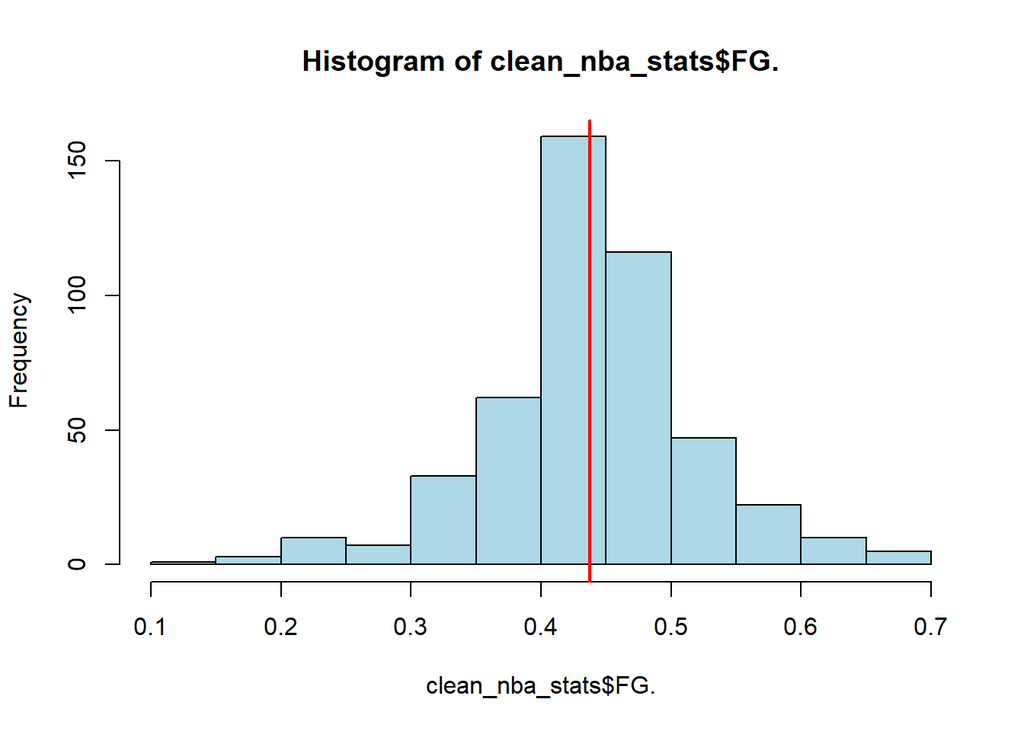

```r
hist(clean_nba_stats$FG., col = "light blue")
abline(v = mean(nba_stats$FG., na.rm = T),
       col = "red",
       lwd = 2)
```

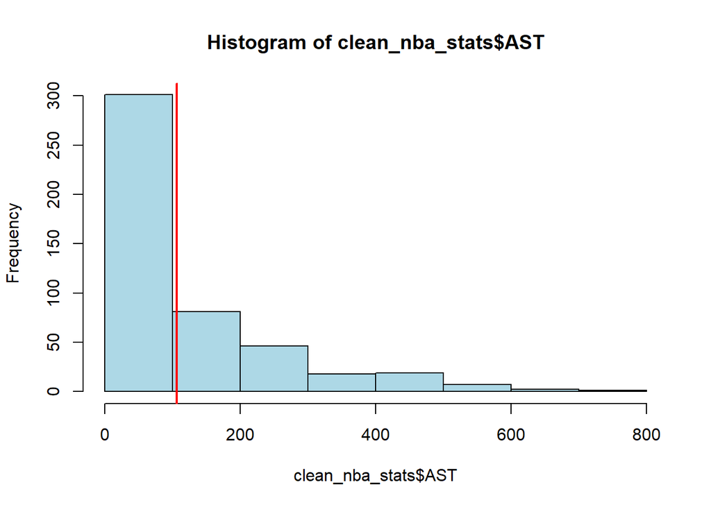

```r
hist(clean_nba_stats$AST, col = "light blue")
abline(v = mean(nba_stats$AST, na.rm = T),
       col = "red",
       lwd = 2)
```

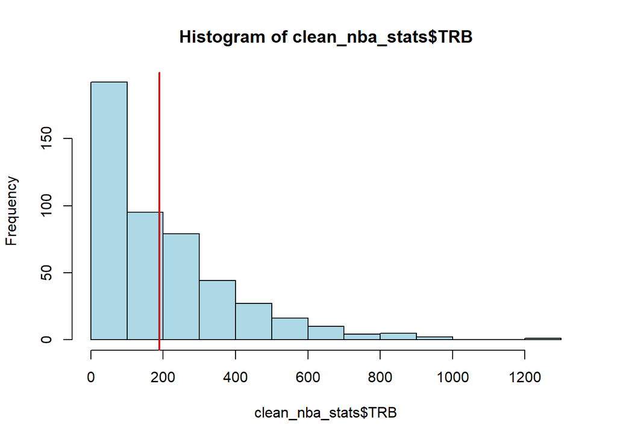

```r
hist(clean_nba_stats$TRB, col = "light blue")
abline(v = mean(nba_stats$TRB, na.rm = T),
       col = "red",
       lwd = 2)
```

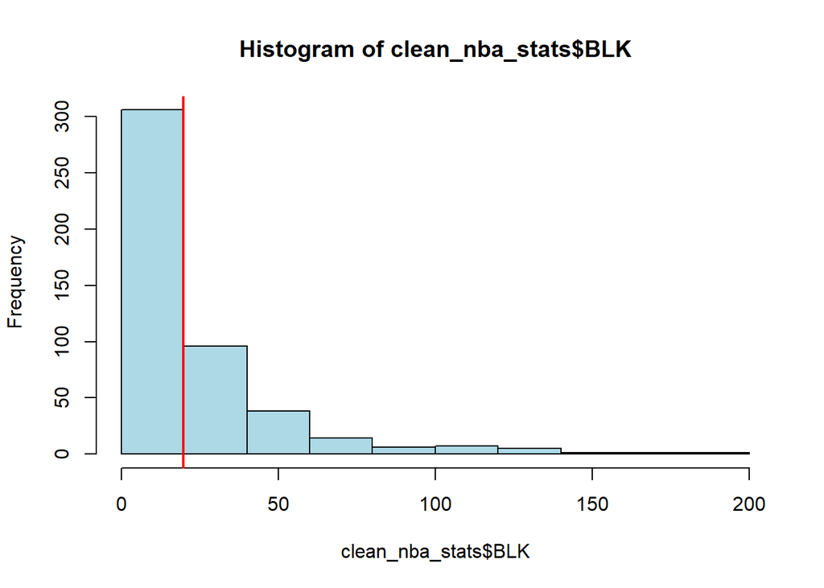

```r
hist(clean_nba_stats$BLK, col = "light blue")
abline(v = mean(nba_stats$BLK, na.rm = T),
       col = "red",
       lwd = 2)
```

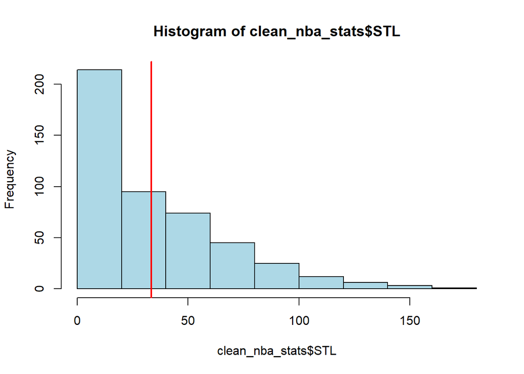

```r
hist(clean_nba_stats$STL, col = "light blue")
abline(v = mean(nba_stats$STL, na.rm = T),
       col = "red",
       lwd = 2)
```

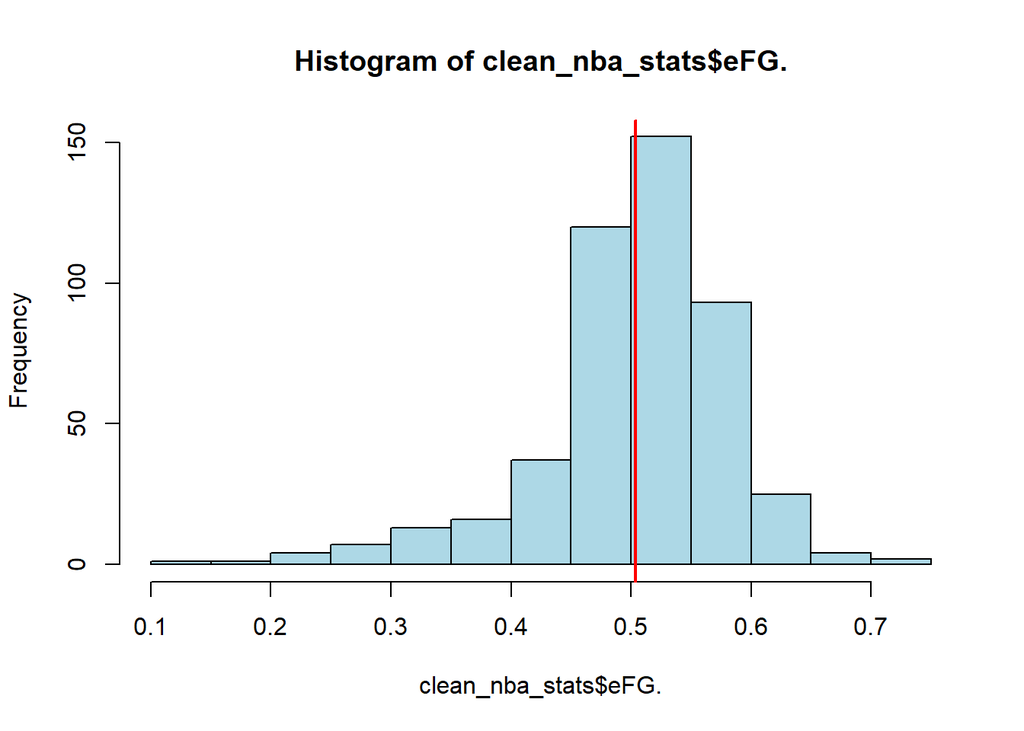

```r
hist(clean_nba_stats$eFG., col = "light blue")
abline(v = mean(nba_stats$eFG., na.rm = T),
       col = "red",
       lwd = 2)
```

# c) To find the relationship between response variable and explanatory variable

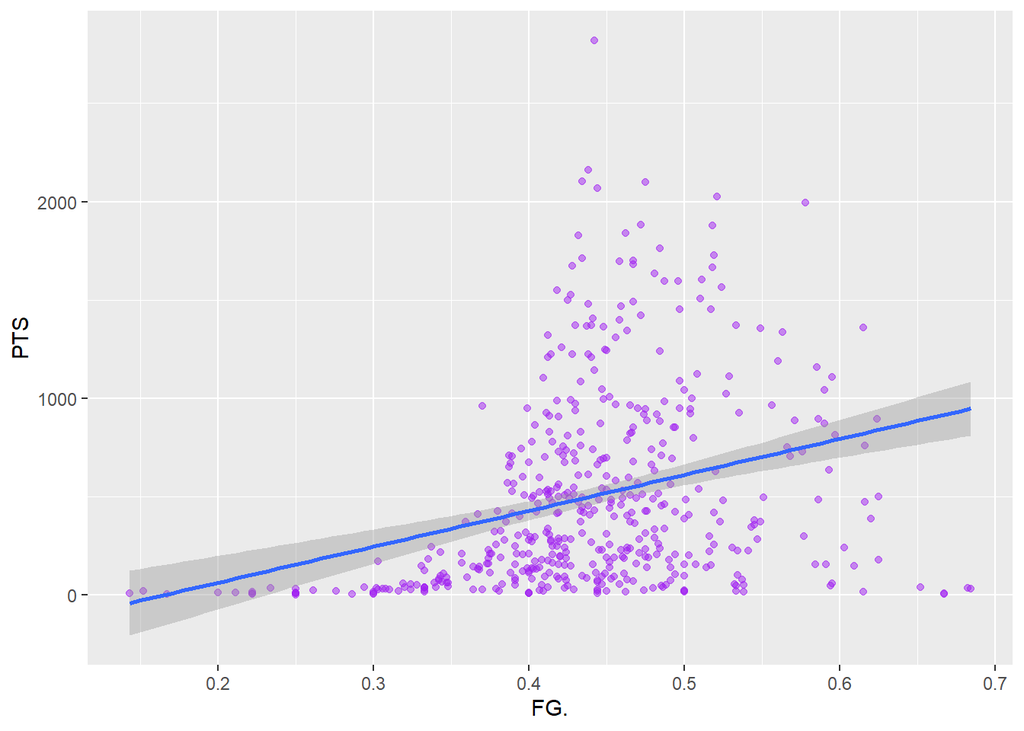

```r
ggplot(clean_nba_stats, aes(x=FG., y=PTS)) + geom_point(alpha=0.5, color="purple") +
  geom_smooth(method = "lm") #by using function ggplot from tidyverse package
```

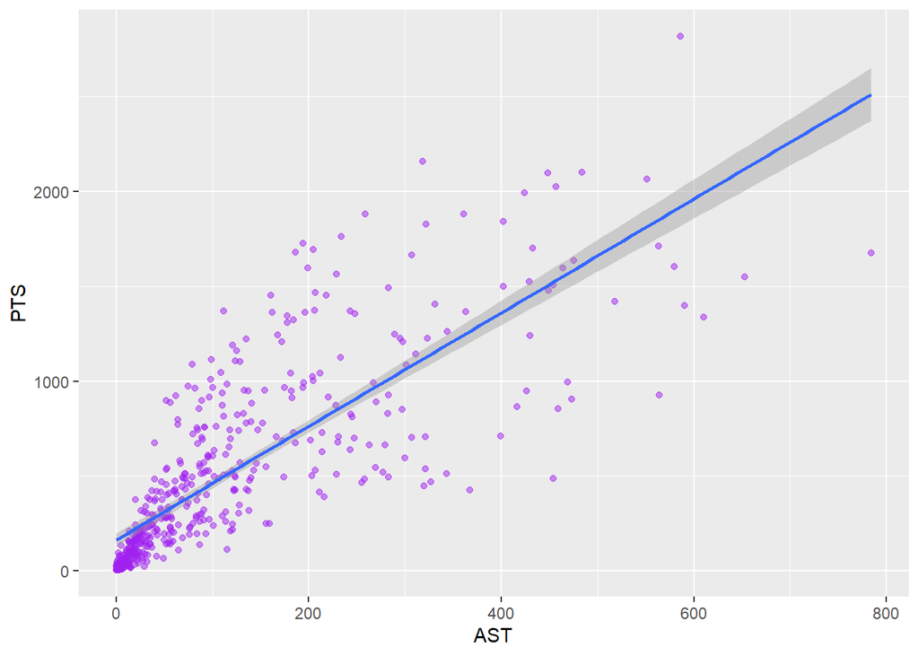

```r
ggplot(clean_nba_stats, aes(x=AST, y=PTS)) + geom_point(alpha=0.5, color="purple") +
  geom_smooth(method = "lm")
```

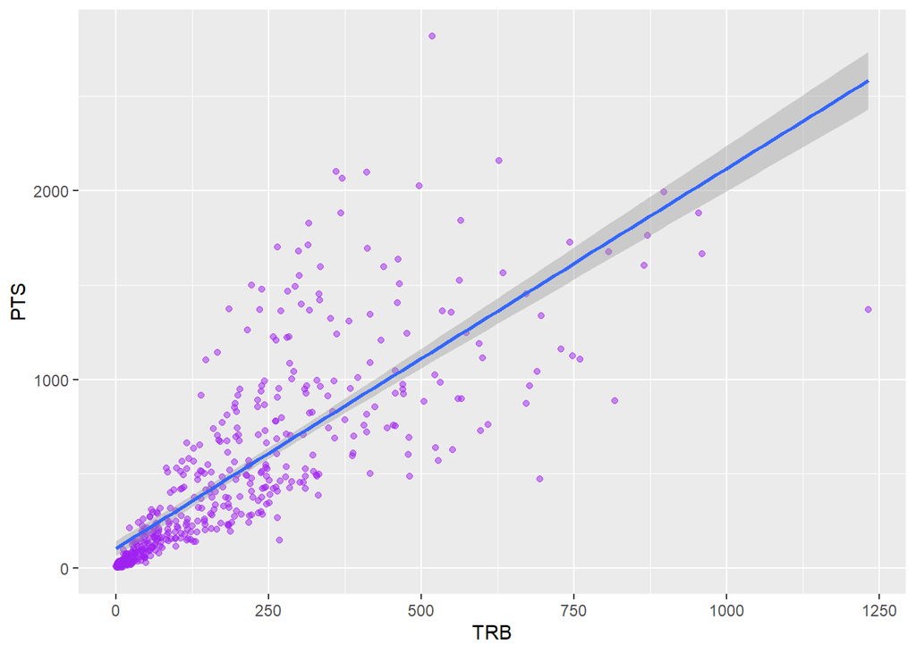

```r
ggplot(clean_nba_stats, aes(x=TRB, y=PTS)) + geom_point(alpha=0.5, color="purple") +
  geom_smooth(method = "lm")
```

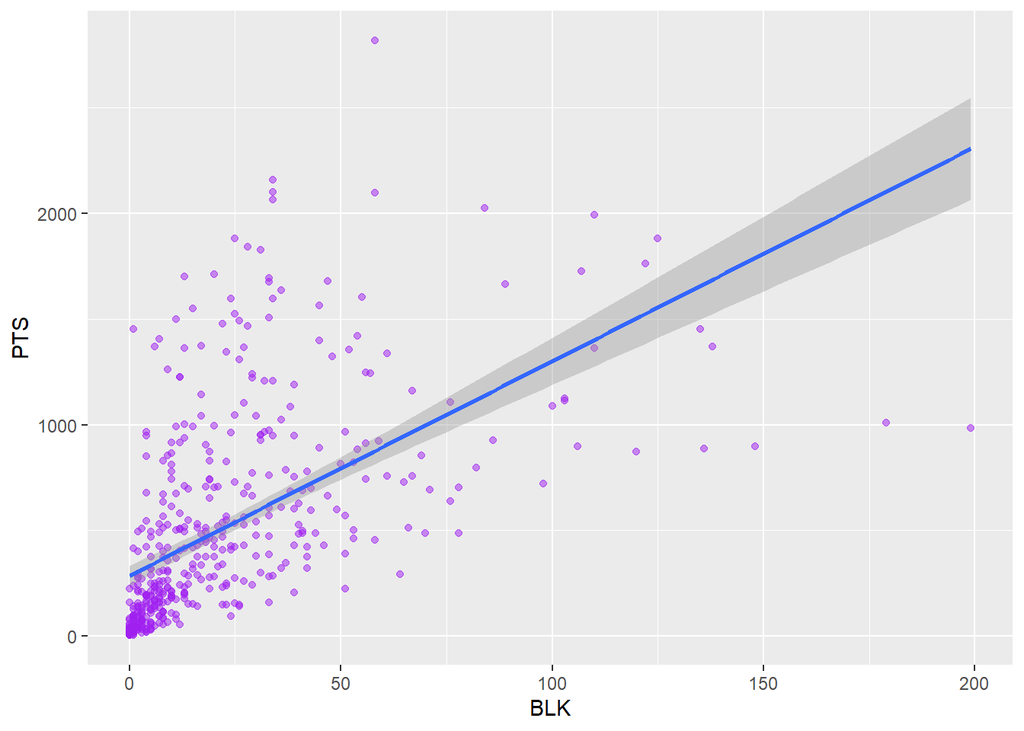

```r
ggplot(clean_nba_stats, aes(x=BLK, y=PTS)) + geom_point(alpha=0.5, color="purple") +
  geom_smooth(method = "lm")
```

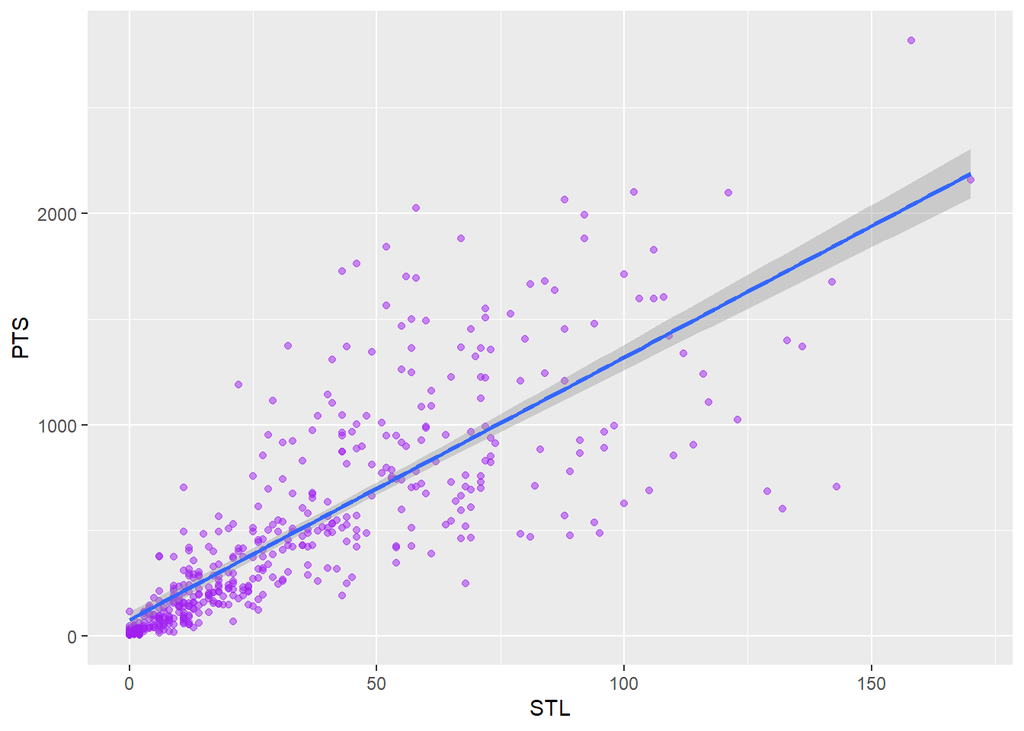

```r
ggplot(clean_nba_stats, aes(x=STL, y=PTS)) + geom_point(alpha=0.5, color="purple") +
  geom_smooth(method = "lm")
```

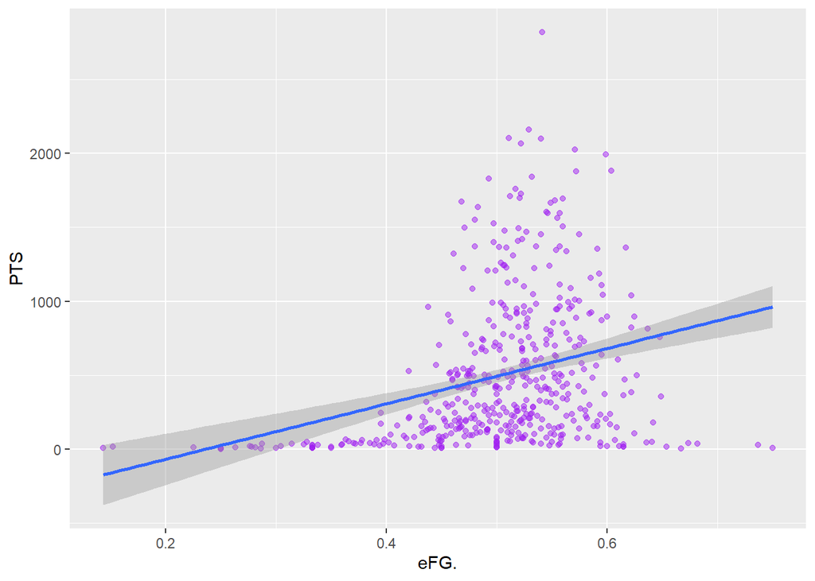

```r
ggplot(clean_nba_stats, aes(x=eFG., y=PTS)) + geom_point(alpha=0.5, color="purple") +
  geom_smooth(method = "lm")
```

# Data Modelling and Results